# Лабораторной работы №6

Дисциплина “Операционные системы”

Обрезкова А.В.

Российский университет дружбы народов, Москва, Россия

ФФМиЕН

18 марта 2023

# Информация

## Докладчик

- Обрезкова Анастасия Владимировна
- студентка направления “Математика и механика”
- Российский университет дружбы народов
- 1132226505@pfur.ru

# Вводная часть

## Цель работы

Ознакомиться с инструментами поиска файлов и фильтрации текстовых данных. Приобретение практических навыков: по управлению процессами (и заданиями), по проверке использования диска и обслуживанию файловых систем.

# Основная часть

## Выполнение лабораторной работы

- Записала в файл file.txt названия файлов, содержащихся в каталоге /etc и в домашнем каталоге

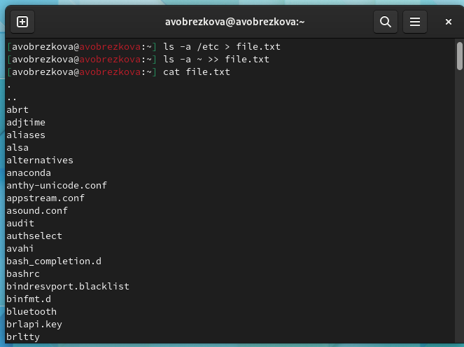

- Вывела имена всех файлов из file.txt, имеющих расширение .conf, после чего записала их в новый текстовой файл conf.txt.

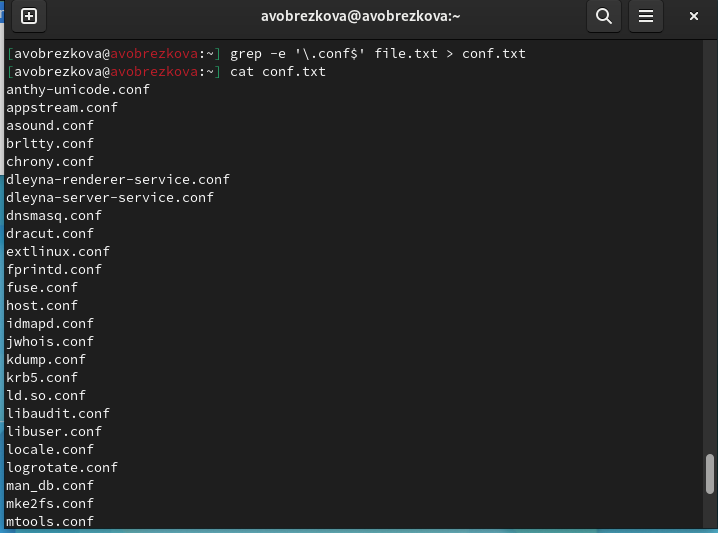

- Определила, какие файлы в моем домашнем каталоге имеют имена, начинавшиеся с символа c.

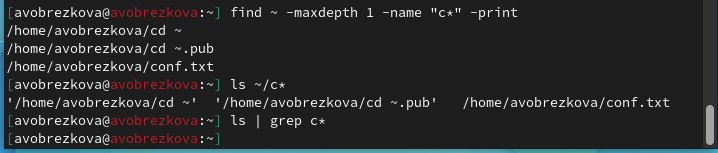

- Вывела на экран (по странично) имена файлов из каталога /etc, начинающиеся с символа h.

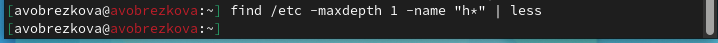

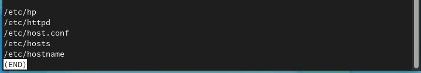

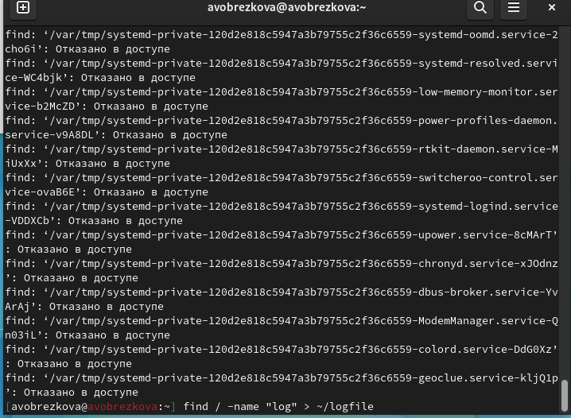

- Удалила файл ~/logfile

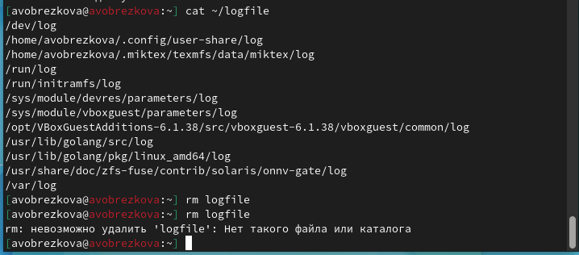

- Запустила из консоли в фоновом режиме редактор gedit. после ввода команды gedit & появляется окно редактора

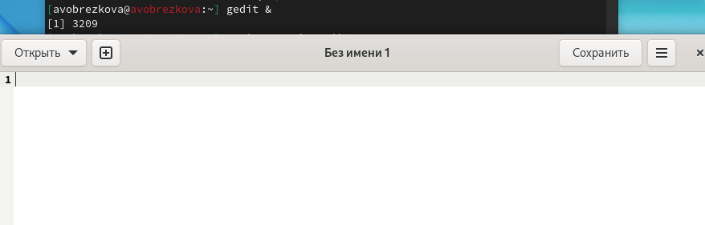

- Определила идентификатор процесса gedit, используя команду ps, конвейер и фильтр grep

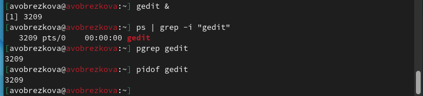

- Прочитала справку (man) команды kill, после чего использовала её для завершения процесса gedit

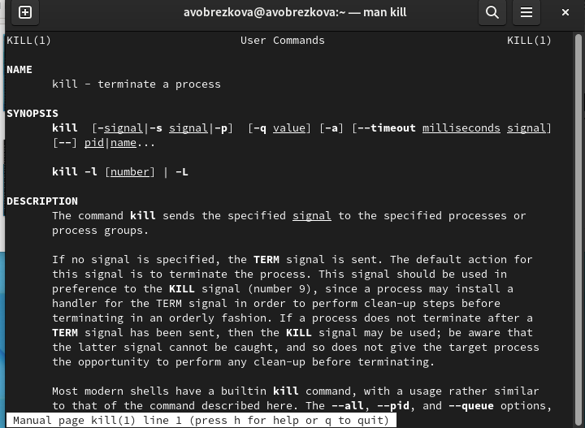

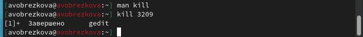

## Команды df и du

- df - утилита, показывающая список всех файловых систем по именам устройств, сообщает их размер, занятое и свободное пространство и точки монтирования

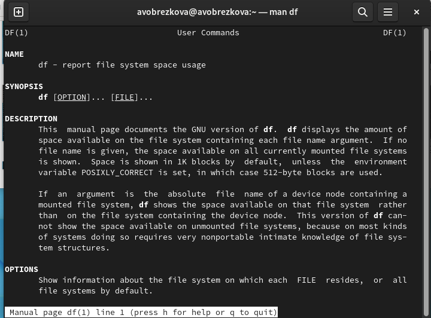

## Команды df и du

- du - утилита, предназначенная для вывода информации об объеме дискового пространства, занятого файлами и директориями. Она принимает путь к элементу файловой системы и выводит информацию о количестве байт дискового пространства или блоков диска, задействованных для его хранения.

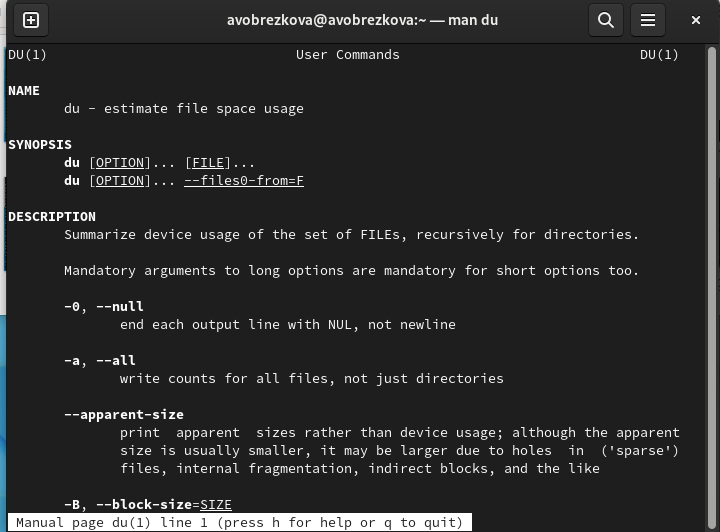

## Команды df и du

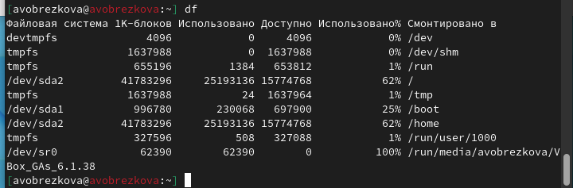

## Команды df и du

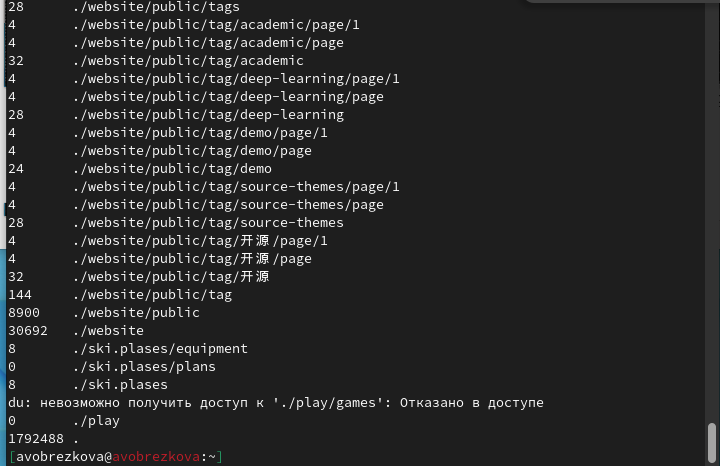

## Команда find

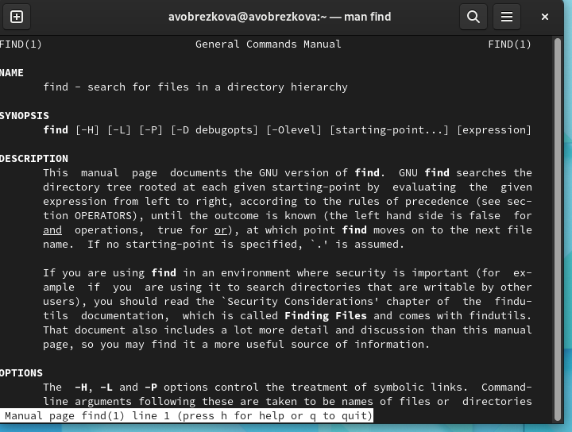

## Команда find

- Вывела имена всех директорий, имеющихся в моем домашнем каталоге

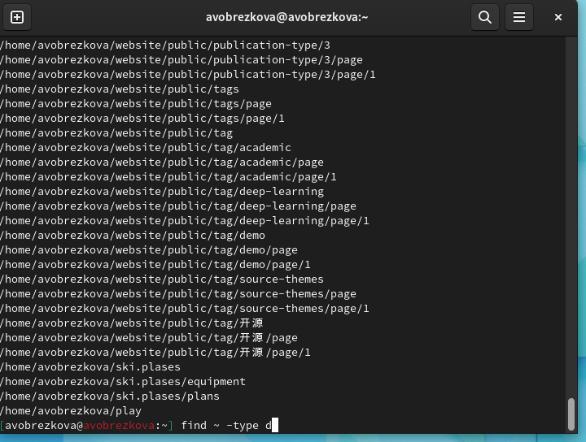

# Заключение

## Вывод

В ходе выполнения данной лабораторной работы я ознакомилась с инструментами поиска файлов и фильтрации текстовых данных, а также приобрела практические навыки по управлению процессами, по проверке использования диска и обслуживанию файловых систем.